# Exercise 2 (20 minutes)

You practice: OLS regression and its interpretation — edge ③. When you're done, assist some of the others …

*(Keep working in the R script from Exercise 1 — you already have `Dat`. If not: the starter code and the "Stuck?" box are in Exercise 1.)*

1. Regress poverty on state ownership of the economy (edge ① again, now as a regression). With a one-unit increase in state ownership, poverty changes by: percentage points (two digits; point or comma is fine).

```r
ols_1 <- lm_robust(poverty ~ state_ownership, data = Dat)

modelsummary(
  list("Poverty" = ols_1),
  statistic = NULL,                 # No statistical inference (yet)
  gof_map = c("nobs", "r.squared")
)
```

|  | Poverty |
| --- | --- |
| (Intercept) | 15.914 |
| state_ownership | 2.742 |
| Num.Obs. | 161 |
| R2 | 0.017 |

2. **Write one sentence** in your R script (as a `# comment`) interpreting that slope — *descriptively*, as in the lecture. Then compare:

*Across 161 countries, one unit more state ownership of the economy (≈ one standard deviation on the V-Dem scale) is associated with, on average, 2.74 percentage points more of the population in extreme poverty.*

(Direction, size, units — and no causal language: "is associated with", not "leads to".)

3. Regress poverty on civil liberties (edge ② as a regression). With a one-unit increase in civil liberties, poverty changes by: percentage points (two digits).

```r
ols_2 <- lm_robust(poverty ~ civ_liberties, data = Dat)

modelsummary(
  list("Poverty" = ols_2),
  statistic = NULL,
  gof_map = c("nobs", "r.squared")
)
```

|  | Poverty |
| --- | --- |
| (Intercept) | 32.503 |
| civ_liberties | -26.738 |
| Num.Obs. | 161 |
| R2 | 0.106 |

*One sentence: countries with a one-unit stronger civil liberties have, on average, 26.7 percentage points less of their population in extreme poverty.*

4. Which of the two is the better model of the variance of poverty across the world?
5. Now the missing edge ③: make a scatter plot with civil liberties on the Y-axis and state ownership of the economy on the X-axis.

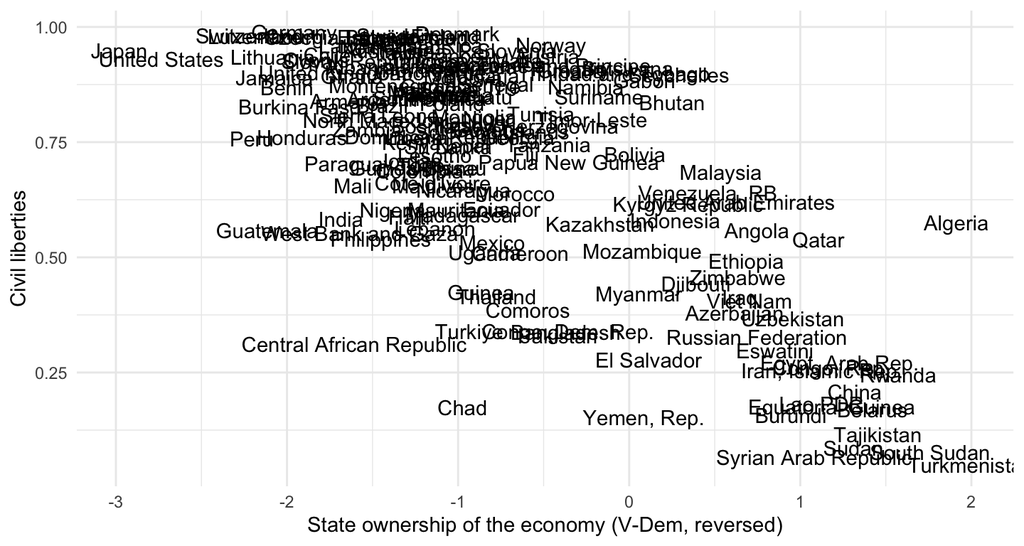

```r
ggplot(data = Dat, aes(y = civ_liberties, x = state_ownership)) +
  geom_text(aes(label = country)) +
  labs(y = "Civil liberties",
       x = "State ownership of the economy (V-Dem, reversed)") +
  theme_minimal()
```

6. **Before computing:** judging from your scatter plot, the correlation on edge ③ is …
7. Regress civil liberties on state ownership. With a one-unit increase in state ownership, civil liberties change by: (two digits).

```r
ols_3 <- lm_robust(civ_liberties ~ state_ownership, data = Dat)

modelsummary(
  list("Civil liberties" = ols_3),
  statistic = NULL,
  gof_map = c("nobs", "r.squared")
)
```

|  | Civil liberties |
| --- | --- |
| (Intercept) | 0.571 |
| state_ownership | -0.176 |
| Num.Obs. | 161 |
| R2 | 0.479 |

8. Make one regression table with all three models — the complete triangle — and **discuss with your neighbour**, in three steps:
   1. Which edge of the triangle shows the *strongest* association, which the *weakest*?
   2. A defender of the trade-off thesis points at China (state-owned, extreme poverty ≈ 0). What do you answer, looking at *all* countries?
   3. Why can none of this be read *causally* (yet)? What would we need?

```r
modelsummary(
  list("Poverty" = ols_1, "Poverty" = ols_2, "Civil liberties" = ols_3),
  statistic = NULL,
  gof_map = c("nobs", "r.squared")
)
```

|  | Poverty | Poverty | Civil liberties |
| --- | --- | --- | --- |
| (Intercept) | 15.914 | 32.503 | 0.571 |
| state_ownership | 2.742 |  | -0.176 |
| civ_liberties |  | -26.738 |  |
| Num.Obs. | 161 | 161 | 161 |
| R2 | 0.017 | 0.106 | 0.479 |

*Talking points:* **(a)** Edge ③ is by far the strongest — state ownership comes with far fewer civil liberties; edge ① is the weakest — no systematic poverty payoff. **(b)** One case is an anecdote; across all countries the average pattern shows no poverty advantage. (And is China's poverty reduction *because of* state ownership, or of markets, growth, or something else entirely?) **(c)** These are descriptive comparisons of *different* countries that differ in many further ways — confounding. What we would need is the topic of the coming weeks: designs and methods that identify causal effects.

**Bonus (for the fast):** rerun edge ① *without* China and Vietnam. Does the conclusion change? What does that tell you about how sensitive our verdict is to single cases?

```r
ols_1b <- lm_robust(poverty ~ state_ownership,
                    data = Dat %>% filter(country != "China" & country != "Viet Nam"))

modelsummary(
  list("All countries" = ols_1, "Without CHN & VNM" = ols_1b),
  statistic = NULL,
  gof_map = c("nobs", "r.squared")
)
```

|  | All countries | Without CHN & VNM |
| --- | --- | --- |
| (Intercept) | 15.914 | 16.417 |
| state_ownership | 2.742 | 3.142 |
| Num.Obs. | 161 | 159 |
| R2 | 0.017 | 0.022 |

The slope barely moves — the "no poverty payoff" conclusion does **not** hinge on the two famous cases. Checking whether results survive removing influential cases is called a *robustness check* — remember it for your term paper.